# Predict salary of programmers in China by supervised learning

#### SVM

Tuning code:

```r
library("e1071")
costs <- c(0.00001,0.0001,0.001,0.01,0.1,1,10)
gammas <- c(0.01,0.02,0.03,0.04,0.05,0.10,0.2,0.3,0.4,0.5)
kernels <- c('linear','polynomial','radial','sigmoid')
svm.tune.result <- expand.grid(cost = costs, gamma = gammas, kernel = kernels)
svm.tune.result['MSE'] <- 0
for (i in costs){
  for (j in gammas){
    for (x in kernels){
      svmfit <- svm(salary_avg ~ ., data=data[train.index,],gamma = j, cost = i, kernel = x, cross = 5)
      svm.tune.result[svm.tune.result$cost == i & svm.tune.result$gamma == j & svm.tune.result$kernel == x,4] <- svmfit$tot.MSE[1]
      print(svmfit$tot.MSE[1])
    }
  }
}

opt.index <- which.min(svm.tune.result$MSE)
opt.cost <- svm.tune.result$cost[opt.index]
opt.gamma <- svm.tune.result$gamma[opt.index]
opt.kernel <- svm.tune.result$kernel[opt.index]
```

After tuning, we get the optimal result:

```r
library("e1071")
opt.cost <- 10
opt.gamma <- 0.01
opt.kernel <- "radial"
opt.svm <- svm(salary_avg ~ ., data=data[train.index,], gamma = opt.gamma, cost = opt.cost, kernel = opt.kernel)
svm.pred <- predict(opt.svm, newdata = x.test)
rmse.svm <- sqrt(mean((svm.pred - y.test)^2))
svm.blender <- predict(opt.svm, newdata = x.blender)
```

#### Ensemble model

Single models are combined together to conduct both a lassso model and a randomForest model.

```r
# combine data
train.data.ensemble <- data.frame(lm.blender,lasso.blender,en.blender,rf.blender,xgb.blender,svm.blender,y.blender)
colnames(train.data.ensemble) <- c("lm","lasso","en","rf","xgb","svm","y")

test.data.ensemble <- data.frame(lm.pred,lasso.pred,en.pred,rf.pred,xgb.pred,svm.pred,y.test)
colnames(test.data.ensemble) <- c("lm","lasso","en","rf","xgb","svm","y")

# lm
x.ensemble.m <- model.matrix(y~.,train.data.ensemble)[,-1]
y.ensemble <- train.data.ensemble$y
x.ensemble.test.m <- model.matrix(y~.,test.data.ensemble)[,-1]
y.ensemble.test <- test.data.ensemble$y

lm.ensemble.cv <- cv.glmnet(x.ensemble.m, y.ensemble, alpha=1)

ensemble.lam <- lm.ensemble.cv$lambda.1se
ensemble.lasso.mod <- glmnet(x.ensemble.m, y.ensemble, alpha=1)

# predicitions
ensemble.lasso.pred <- predict(ensemble.lasso.mod, newx=x.ensemble.test.m, s=ensemble.lam)
rmse.ensemble.lm <- sqrt(mean((ensemble.lasso.pred - y.ensemble.test)^2))
```

Since random forest performs better than linear model here, we choose it as the final ensemble model.

```r
# random forest
set.seed(123)
rf.ensemble <- randomForest(y ~ ., data=train.data.ensemble)
rf.ensemble.pred <- predict(rf.ensemble,newdata = test.data.ensemble[,-7])
rmse.rf.ensemble <- sqrt(mean((rf.ensemble.pred-test.data.ensemble[,7])^2))
```

### Model Comparison

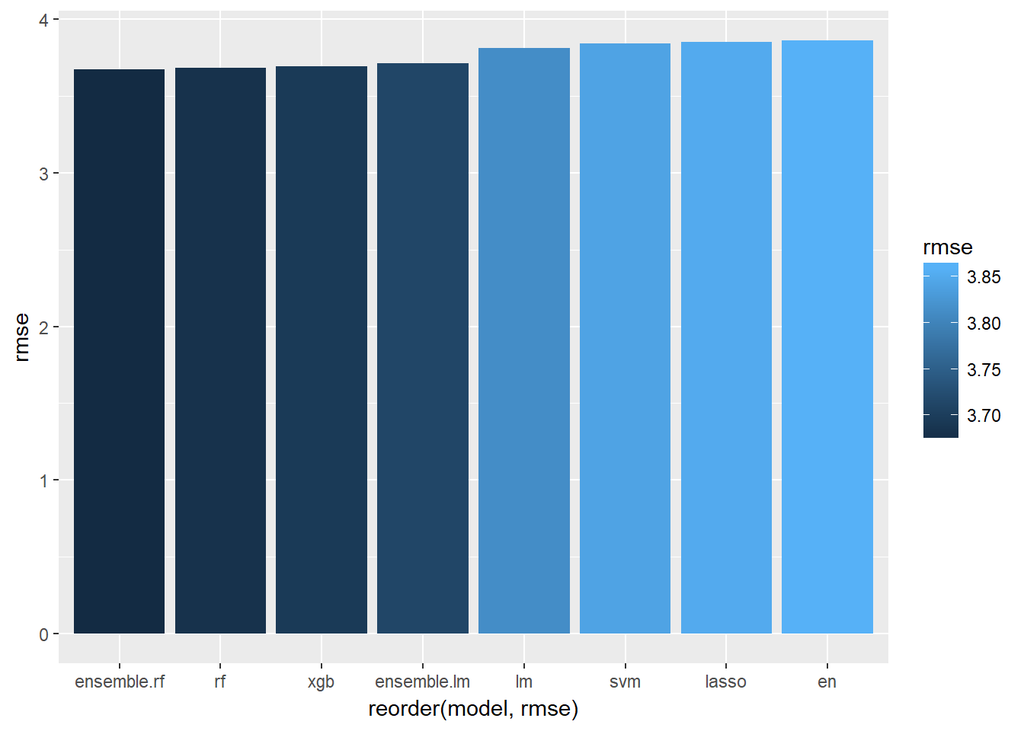

```r
library(ggplot2)
model <- c('en','lasso','lm','rf','svm','xgb','ensemble.lm','ensemble.rf')
rmse <- c(rmse.en,rmse.lasso,rmse.lm,rmse.rf,rmse.svm,rmse.xgb,rmse.ensemble.lm,rmse.rf.ensemble)
comparison <- data.frame(model,rmse)
comparison <- comparison[order(comparison$rmse),]
ggplot(data = comparison) + geom_col(aes(reorder(model, rmse),rmse,fill=rmse))
```

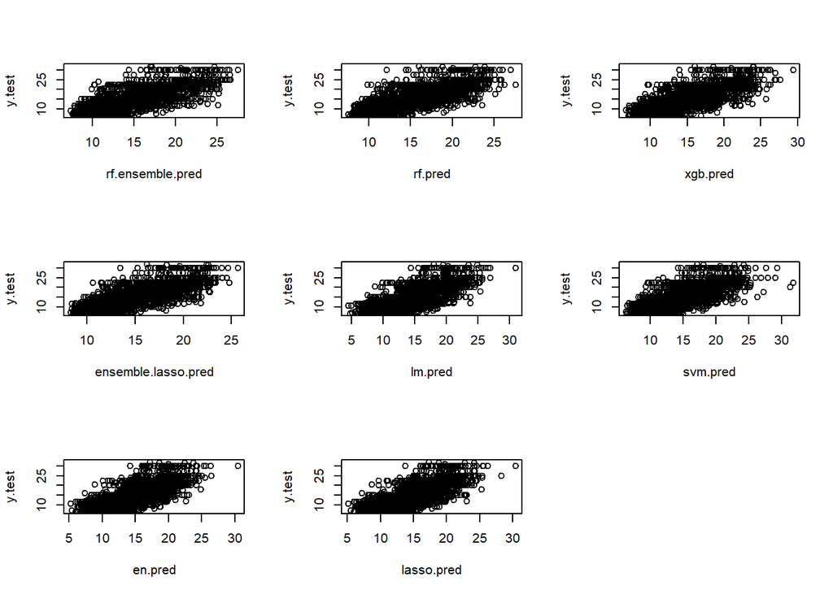

```r
par(mfrow=c(3,3))
plot(rf.ensemble.pred,y.test)
plot(rf.pred,y.test)
plot(xgb.pred,y.test)
plot(ensemble.lasso.pred,y.test)
plot(lm.pred,y.test)
plot(svm.pred,y.test)
plot(en.pred,y.test)
plot(lasso.pred,y.test)
```

On an overall aspect, ensemble model using random forest performs the best. Tree based methods like random forest and xgboost follow, while linear models perform a little bit worse. In addition, some problems that can be seen from the prediction plot are as follows:

1. linear regressions like EN, lm, lasso don’t perform well in predicting high salaries. The predictions of high salaries in linear model tend be lower than real value.
2. Tree based methods like random forest and xgboost perform better in high salary part, but have higher variance in the middle level salary predictions. This is because tree-based methods take average of leaf nodes to be predictions while linear regression will be relatively fixed by middle level majority data, thus not able to predict extreme values well.

## 3. Conclusion

- Ensemble random forest model performs the best within all the models, whose RMSE is 3.68. This means that on average the prediction and the real salary differ around 3.68 (k).
- On the company side, location, reputation and series level of the company affect a programmer’s salary most.
- On individual side, work experience, education and programming languages have effect on programmer’s salary.
- If you are looking forward to high income and planning to work as a programmer, learn Python and try to find companies in series C or D, this gives the highest probability for your to be paid high.

## 4. Future Scope

- Our data has some limitation, because most of our variables are categorical variables, which might not be strong enough to provide enough information for the model regression. We might need to search for more numeric data to predict a better result.
- The salary data we are using is only a claimed salary released on job hunting websites, which is different from the real salary data, we can try to find more accurate salary data to do the prediction.
- In feature engineering, we split the position name information into many different dummies. However, some of the names are not clean and word splitting done by JiebaR has some mistakes, which might lead to information loss and dummy imbalance, we can try to find better ways to extract information from position names.

*[THE END]*